# Data Mining

G. Holt Williams

6/10/2020

# Introduction

The purpose of this report is to practice data minning techniques in R, including classifying and clustering methods. The project is broken down into two main sections. The first being an exploratory analysis of the data set chosen, then followed by data minning of the dataset

# Data Minning Assignment

## Load Librairies

To begin the analysis the requisite packages need to be loaded into the workspace.

```r
library(tidyverse)
library(printr)
library(psych)
library(ggcorrplot)
```

## Data Processing

Next the chosen dataset needs to be loaded. For this assignment the UCI Machien Learning Repository’s Wine Quality data set was chosen (http://archive.ics.uci.edu/ml/datasets/Wine+Quality). This dataset was chosen for its large sample size and due to the preprocessing UCI applies to limit additional cleaning steps. The code to load the dataset and clean it is as follows:

```r
# load data Set
red<-read.csv("winequality-red.csv", sep=";")
white<-read.csv("winequality-white.csv", sep=";")
## Add type variable
red$type<-"red"
white$type<-"white"
#Combine
wine<-rbind(red,white)
wine$type<-as.factor(wine$type)
table(wine$quality)
```

| 3 | 4 | 5 | 6 | 7 | 8 | 9 |
| --- | --- | --- | --- | --- | --- | --- |
| 30 | 216 | 2138 | 2836 | 1079 | 193 | 5 |

```r
## Make Quality Factor
wine$qualityFact<-as.factor(wine$quality)
wine$qualityFact<-fct_collapse(wine$qualityFact, Bad = c("3", "4"), Med = c("5","6","7"), Great=c("8","9"))
table(wine$qualityFact)
```

| Bad | Med | Great |
| --- | --- | --- |
| 246 | 6053 | 198 |

```r
table(wine$quality)
```

| 3 | 4 | 5 | 6 | 7 | 8 | 9 |
| --- | --- | --- | --- | --- | --- | --- |
| 30 | 216 | 2138 | 2836 | 1079 | 193 | 5 |

## Tables and Plots

```r
wine%>%describe(quant=c(.25,.75),omit=TRUE)%>%select(n, sd,mean, median, min, max, Q0.25, Q0.75)%>%round(digits=2)
```

|  | n | sd | mean | median | min | max | Q0.25 | Q0.75 |
| --- | --- | --- | --- | --- | --- | --- | --- | --- |
| fixed.acidity | 6497 | 1.30 | 7.22 | 7.00 | 3.80 | 15.90 | 6.40 | 7.70 |
| volatile.acidity | 6497 | 0.16 | 0.34 | 0.29 | 0.08 | 1.58 | 0.23 | 0.40 |
| citric.acid | 6497 | 0.15 | 0.32 | 0.31 | 0.00 | 1.66 | 0.25 | 0.39 |
| residual.sugar | 6497 | 4.76 | 5.44 | 3.00 | 0.60 | 65.80 | 1.80 | 8.10 |
| chlorides | 6497 | 0.04 | 0.06 | 0.05 | 0.01 | 0.61 | 0.04 | 0.06 |
| free.sulfur.dioxide | 6497 | 17.75 | 30.53 | 29.00 | 1.00 | 289.00 | 17.00 | 41.00 |
| total.sulfur.dioxide | 6497 | 56.52 | 115.74 | 118.00 | 6.00 | 440.00 | 77.00 | 156.00 |
| density | 6497 | 0.00 | 0.99 | 0.99 | 0.99 | 1.04 | 0.99 | 1.00 |
| pH | 6497 | 0.16 | 3.22 | 3.21 | 2.72 | 4.01 | 3.11 | 3.32 |
| sulphates | 6497 | 0.15 | 0.53 | 0.51 | 0.22 | 2.00 | 0.43 | 0.60 |
| alcohol | 6497 | 1.19 | 10.49 | 10.30 | 8.00 | 14.90 | 9.50 | 11.30 |
| quality | 6497 | 0.87 | 5.82 | 6.00 | 3.00 | 9.00 | 5.00 | 6.00 |

Each of these variables, except quality, are the inherent characteristics of the wine gatherred through scientific tests. The quality variable is an average of a panel of experts rating the wine. There are a total of 6497 wines in the dataset, broken down into 1599 red wines and 4898 white wines. Below is a plot to show the correlation of each variable.

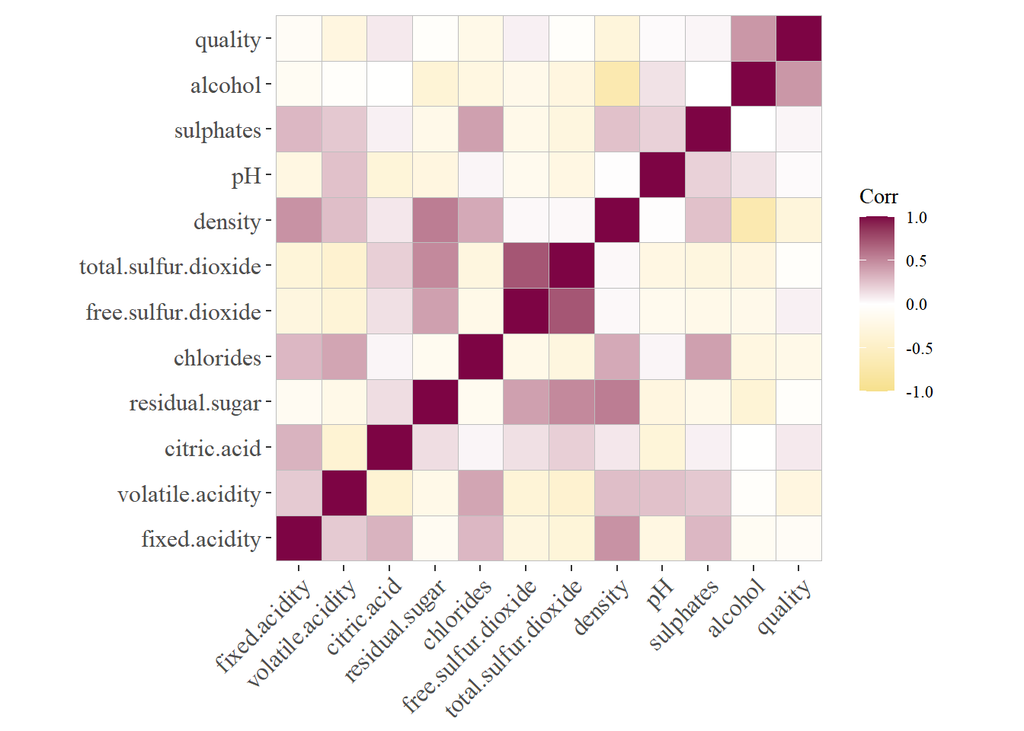

```r
ggcorrplot(round(cor(wine[1:12]),2), ggtheme=theme_tufte(),colors = c("#F6E08C", "white", "#7D0444"))
```

Many of the independant variables here are correlated, but interstingly only alcohol has a higher than average correlation with quality at 0.44. Some other noteworthy points is the interaction of density, residual sugar, and alcohol (content). As alcohol goes down, the residual sugar increases,a dn density increases. This mimics a simple understanding of the wine making process of yeast eating the sugar to produce alcohol and making it less dense. Because this assignment looks partially at prediction by segmentign the data into test and train, correlated variables will not be removed. If instead the outcome was to intrepret the model, it would make sense to remove highly correlated variables.

```r
table(wine$type,wine$qualityFact)
```

| / | Bad | Med | Great |
| --- | --- | --- | --- |
| red | 63 | 1518 | 18 |
| white | 183 | 4535 | 180 |

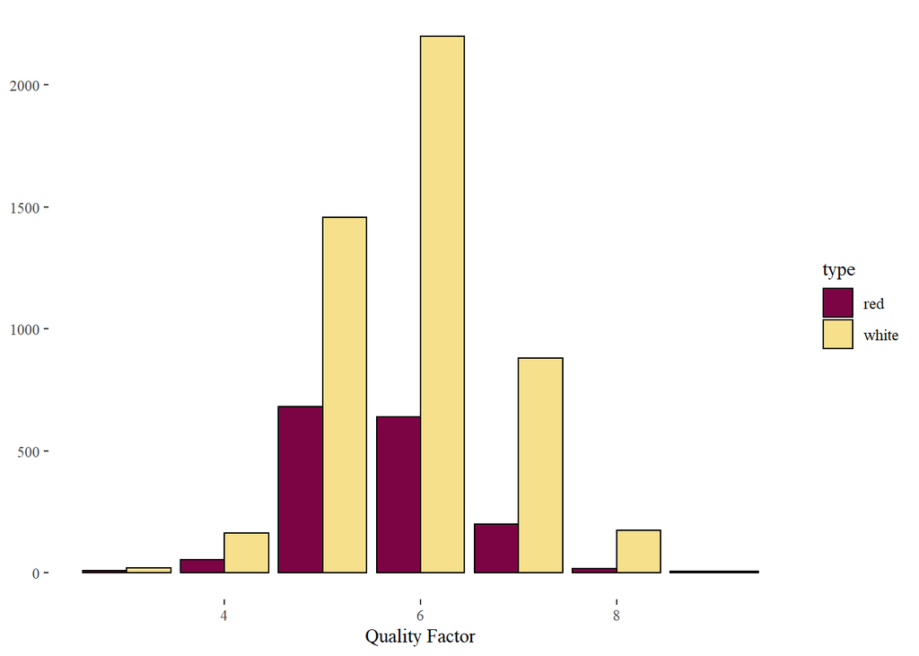

```r
wine%>%ggplot()+
  geom_bar(aes(x=quality, fill=type),color="black", position=position_dodge())+
  theme_tufte()+
  scale_fill_manual(values = c("red"="#7D0444","white"="#F6E08C"))+
  xlab("Quality Factor")+
  ylab(NULL)
```

Here we can see the majority of quality ratings are between 5 and 7 under the Medium category, and this holds true for both red and white wines.

## Data Minning

```r
library(factoextra)
library(NbClust)
library(party)
library(fpc)
```

### Classification

First data mining technique employed is classification, where the outcome is to try and classify the dataset as either Red or White wine. Both the quality and quality factor variable have been removed as they would be considerred outcome variables, and in testing had no outcome in the predictions. The dataset has been split into both training and testing to practice prediction using decision trees.

[figure not shown]

```r
set.seed(1234)
ind <- sample(2, nrow(wine), replace=T, prob=c(0.7, 0.3))
wine.train <- wine[ind==1,-c(12,14)]
wine.test <- wine[ind==2, -c(12,14)]

wine.form<- type ~ .
wine.ctree <- ctree(wine.form,data=wine.train)
plot(wine.ctree)
```

Next, the model developed above is used to predict the test set type of wine .

```r
pred<- predict(wine.ctree, newdata=wine.test)
table(pred, wine.test$type)
```

| pred/ | red | white |
| --- | --- | --- |
| red | 428 | 16 |
| white | 30 | 1444 |

Overall, the model was rather succesful only failing to correctly classify 46 of 1918 total predictions.

### Kmeans Clustering

```r
set.seed(1234)
wine2<- wine[,c(1:11,13)]
wine2$type<- NULL

wine.kmeans<- kmeans(wine2,2)
table(wine$type, wine.kmeans$cluster)
```

| / | 1 | 2 |
| --- | --- | --- |
| red | 1514 | 85 |
| white | 1294 | 3604 |